# MachineLearning(R)

Cinzia Zullian

2022-09-26

## Data Inicial

Todos los datos iniciales fueron recogidos por GeoData Consultants Ltd. Este dataset cuenta con 59400 registros en train y 14850 para el train, los cuales cuentan con las siguientes 40 variables:

amount_tsh - Total static head (cantidad de agua disponible en el punto de agua) - Integer 0 to 350000

date_recorded - Fecha en la cual se ingresó el registro - desde el 2002-10-14 hasta el 2013-12-03

funder - persona que financió el pozo - Character

gps_height - altitud del pozo - Integer from -90 to 2770

installer - organización que realizó la instalacion - Character

longitude - coordenada GPS - Numeric

latitude - coordenada GPS- Numeric

wpt_name - nombre del punto de agua- Character

num_private - - Integer from 0 to 1776

basin - Cuenca hidrográfica geográfica - Factor w/ 9 levels

region_code -código de la región- Factor w/ 26 levels

district_code - código del distrito - Factor w/ 20 levels

lga - localización geográfica - Factor w/ 125 levels

ward - localización geográfica - Character

population - Población alrededor del pozo - Integer from 0 to 305000

public_meeting - True/False - Factor w/ 2 levels

recorded_by - Groupo que registró - Factor w/ 1 level

scheme_management- Persona que opera el punto de agua - Factor w/ 12 levels

scheme_name - Who operates the waterpoint - Character

permit - Si el punto de agua es permitido - Factor w/ 2 levels

construction_year -Año en el que fue construido el punto de agua - Integer from 0 (year NA) to 2013.

extraction_type - Tipo de extracción que utiliza - Factor w/ 17 levels

extraction_type_group - TTipo de extracción que utiliza - Factor w/ 13 levels

extraction_type_class - Tipo de extracción que utiliza - Factor w/ 5 levels

management - Como se gestiona el punto de agua- Factor w/ 12 levels

management_group - Como se gestiona el punto de agua- Factor w/ 6 levels

payment - Lo que cuesta el agua- Factor w/ 7 levels

payment_type - Calidad del agua- Factor w/ 7 levels

water_quality - Calidad del agua - Factor w/ 8 levels

quality_group - Calidad del agua - Factor w/ 6 levels

quantity - Cantidad de agua - Factor w/ 5 levels

quantity_group - TCantidad de agua - Factor w/ 5 levels

source - La fuente del agua- Factor w/ 10 levels

source_type - La fuente del agua - Factor w/ 7 levels

source_class - La fuente del agua - Factor w/ 3 levels

waterpoint_type - Tipo de fuente de agua - Factor w/ 7 levels

waterpoint_type_group - Tipo de fuente de agua - Factor w/ 6 levels

status_group - estado en el que se encuentra la bomba- Factor w/ 3 levels: “functional”, “functional needs repair”, “non functional” *** the dependent variable

# Carga de datos y librerías utilizadas.

```r
suppressPackageStartupMessages({
library(data.table)  # Procesado de datos ultra-rapido
  library(tidytable)   # Dplyr para data.table
  library(ggplot2)     # Graficos
  library(inspectdf)   # EDA automaticos
  library(magrittr)    # Piping capabilities
  library(ranger)      # RandomForest - C++ ultrarapido
  library(tictoc)      # Medida del tiempo de ejecucion
  library(tibble)      # Otro tipo de data.frame
  library(forcats)     # Tratamiendo de variables facil
  library(ggeasy)      # Ggplot facil
  library(missRanger)  # Imputacion de NAs con random forest
  library(stringi)     # Expresiones regulares ultra rapido
  library(dplyr)
  library(xgboost)
  library(corrplot)
  library(visdat)
  library(jtools)
  library(lubridate)   # Tratamiento de fechas
  library(gmt)         # Distancia geografica
  library(mlr)         # Machine Learning en R
  library(h2o)
  library(autoxgboost)
}
)
```

```r
setwd("C:\\Users/cinzi/OneDrive/Escritorio/Big_Data_Complutense/Machine Learning/R/")
trainOri    <- fread("./data/Train.csv")
testOri     <- fread("./data/Test.csv")
trainOriLab <- fread("./data/Train_labels.csv")
trainOriLab2 <- fread("./data/Train_labels.csv")
correlat<- trainOri %>% inner_join(trainOriLab, by = "id")
```

# Análisis de Variables

### EDA (Exploratory Data Analysis)

Los gráficos más relevantes para la limpieza de los datos en el presente trabajo, fueron los siguientes:

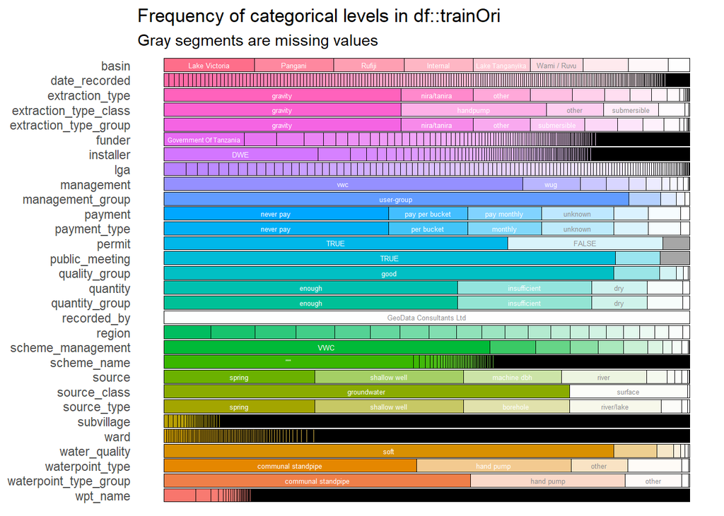

```r
# Realizamos un barplot horizontal con las variables categóricas
x <- inspect_cat(trainOri)
show_plot(x)
```

En este gráfico vemos que existen variables (funder,installer,scheme_name, subvillage, ward y wpt_name) con un gran número de categorías, esto produce que el modelo no reciba buena señal para captar patrones, en las variables que se presentan estos casos puede conllevar a un error el crear dummies o onehot encoding, así que se puede optar por el Lumping para agrupar categorías pequeñas entre sí. Por el contrario la variable Recorded_by es una constante y por lo tanto, no tiene ningún valor más que informativo.

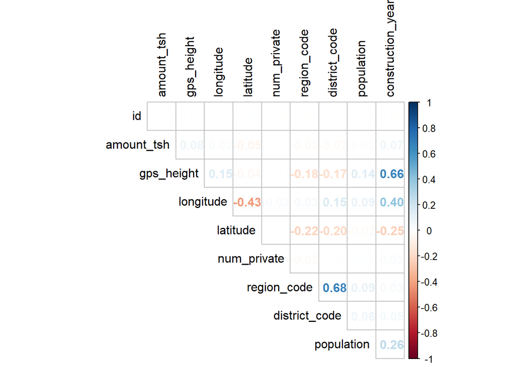

```r
#Correlación entre variables numéricas e intervalos de confianza de esa correlación
num_var<- correlat %>% select.(where(is.numeric))


corrplot(cor(num_var),
         method = "number",
         type = "upper",
         diag = FALSE,
         tl.col = "black",
         bg = "white",
         col = NULL)
```

La correlación de las primeras variables que aparecen en el gráfico, no son excesivas si tomamos en consideración que existen algortmos de procesamiento capaces de funcionar bien con variables que presentan correlaciones y multicolinealidades alrededor del 0.7-0.8. Por tal motivo, se puede continuar con estas variables, siempre que los algoritmos que se utilicen, sean adecuados.

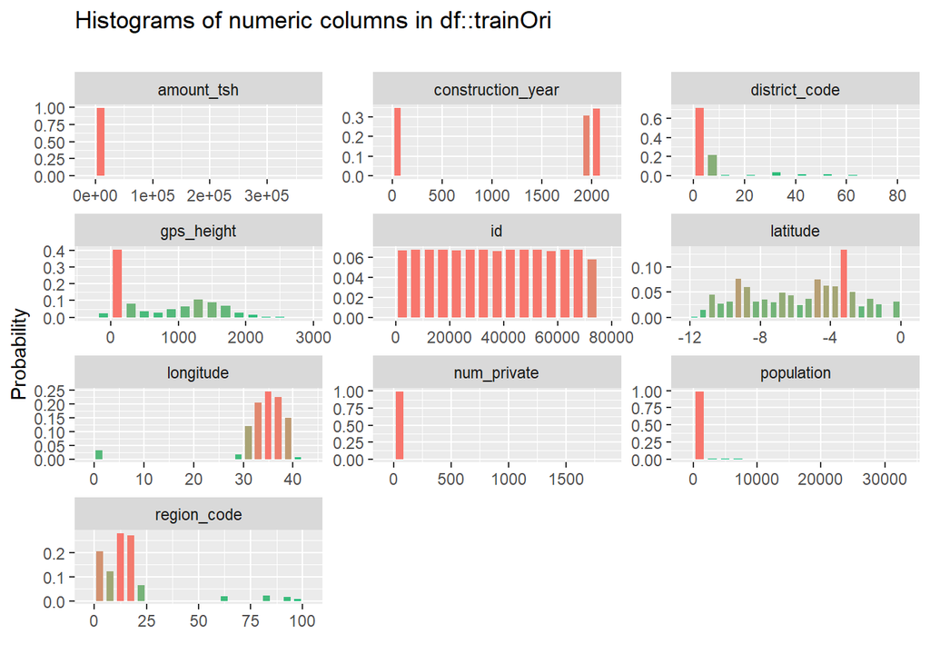

```r
# Histogramas para las columnas numéricas
x <- inspect_num(trainOri)
show_plot(x)
```

Se puede observar que existe un comportamiento similar en la mayoría de variables numéricas en los regitros 0 y negativos, estos pueden tratarse de datos faltantes enmascarados.

Observaciones particulares:

- Amount_tsh : contiene valores extremos
- Constructions_year: no deberían existir valores en 0, estos seguramente se deben a NAs disfrazados
- Gps_height: es sospechoso que existan valores negativos en la altura Longitude tiene valores atípicos en 0, están completamente fuera de rango
- Latitude tiene valores negativos que no corresponden con latitudes de Tanzania

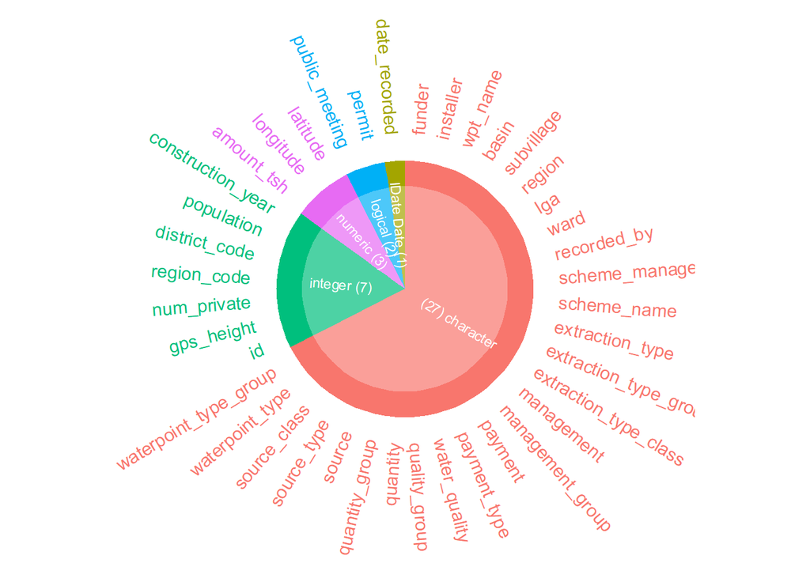

```r
# Barplot de cada tipo de columna
x <- inspect_types(trainOri)
show_plot(x)
```

De las 40 variables, 27 son categóricas, 10 son numéricas, 2 son lógicas y 1 es fecha.

#### Detección de Missing

```r
#Unimos ficheros train y test
traintestOri <- rbind(trainOri, testOri)

#En Tanzania no hay valores de longitud 0
traintestOri$longitud[traintestOri$longitud == 0] <- NA
#En Tanzania no hay valores de altitud negativos porque esta sobre el nivel del mar
traintestOri$gps_height[traintestOri$gps_height <= 0] <- NA
#En Tanzania no existen latitudes de -2e-08
traintestOri$latitude[traintestOri$latitude==-2e-08] <- NA
```

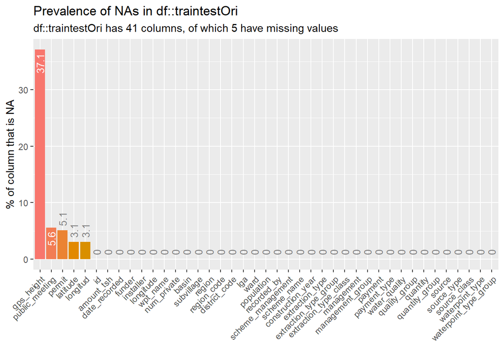

```r
x <- inspect_na(traintestOri)
show_plot(x)
```

A las variables en las que se pudo detectar los valores perdidos son gps_height,latitude public_meeting,permit y longitud. Adicionalmente se puede verificar si existe correlación entre los datos perdidos

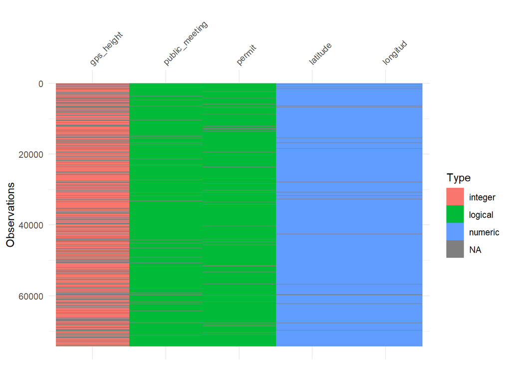

```r
#Para numericas+logicas

Na_colums<-  apply(X = is.na(traintestOri), MARGIN = 2, FUN = sum)>0

Selec_NA<-Na_colums[Na_colums==TRUE]

numlogi<- traintestOri %>% select.( names(Selec_NA))

vis_dat(numlogi)
```

Vemos que los datos perdidos de latitud y longitud tienen el mismo patrón, lo que quiere decir que cuando fue registrado el dato, ninguna de las coordenadas se pudo localizar.En las otras variables no se observa ningún patrón, por lo cual la imputación de perdidos será más eficiente si contempla todos los valores del registro, como es el caso de Ranger.

#### Imputación de Missings

```r
# Usamos Random Forest
tic()
traintestOriImp <- missRanger(traintestOri,
                              pmm.k = 5,
                              num.trees = 250,
                              #maxiter = 200,
                              seed = 1234)
toc(func.toc = toc.outmsg)

# Comprobamos si se han imputado todos los NAs
sum(is.na(traintestOriImp))
```

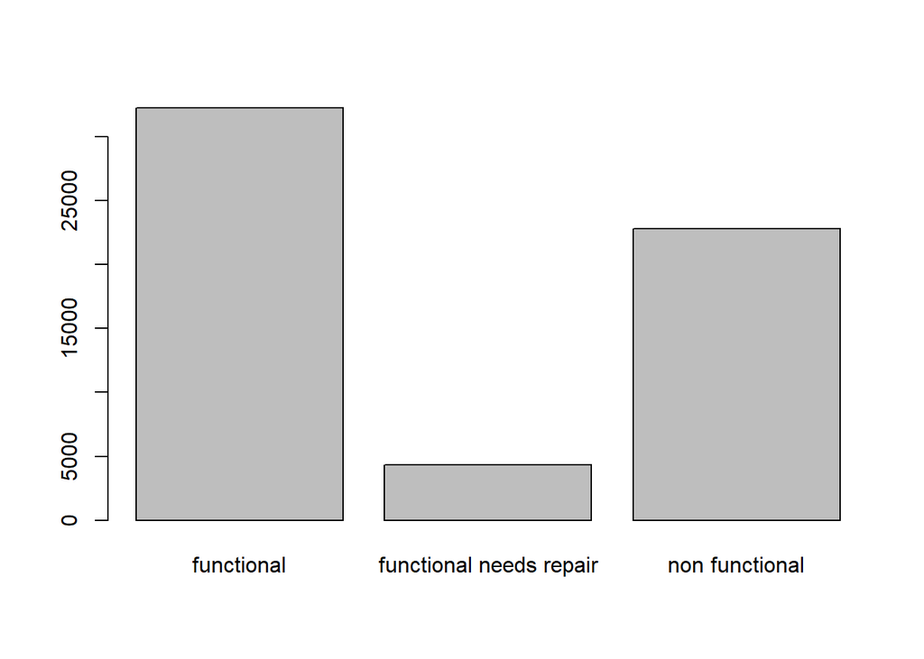

```r
plot(as.factor(trainOriLab$status_group))
```

```r
# Numero de categorías en cada variable
cat_df <- traintestOri %>%
  select.(where(is.character)) %>%
  mutate.(across.(where(is.character), ~ length(unique(.x)))) %>%
  distinct.() %>%
  pivot_longer.() %>% # transponer, para visualizar mejor la informacion
  arrange.(value) %>% # ordeno
  #filter.(value > 1) %>% # filtro las que tienen mas de una categoria
  as.data.table()
cat_df
```

| name | value |
| --- | --- |
| recorded_by | 1 |
| source_class | 3 |
| management_group | 5 |
| quantity | 5 |
| quantity_group | 5 |
| quality_group | 6 |
| waterpoint_type_group | 6 |
| extraction_type_class | 7 |
| payment | 7 |
| payment_type | 7 |

[output cut: 17 more lines]

| name <chr> | value <int> |  |  |  |
| --- | --- | --- | --- | --- |
| recorded_by | 1 |  |  |  |
| source_class | 3 |  |  |  |
| management_group | 5 |  |  |  |
| quantity | 5 |  |  |  |
| quantity_group | 5 |  |  |  |
| quality_group | 6 |  |  |  |
| waterpoint_type_group | 6 |  |  |  |
| extraction_type_class | 7 |  |  |  |
| payment | 7 |  |  |  |
| payment_type | 7 |  |  |  |

Como se había observado anteriormente, la variable recorded_by, es una constante, por lo tanto se puede eliminar del modelo, sin ningún perjuicio asociado a ello. Adicionalmente, cabe destacar que existen 6 variables categóricas que contienen un número muy elevado de categorías. Al ser variables categóricas, se debe verificar con mayor cuidado que tengan consistencia y calidad, ya que resulta mucho más fácil cometer errores de digitación. Para ello se hace necesario recurrir a expresiones regulares que permitan transformar los datos escritos erroneamente.Por otra parte, se observa que de las 30 regiones de Tanzania, sólo se cuenta con 21 de ellas.

```r
limp_text <- function(text) {
  stri_trans_tolower(
    stri_replace_all_regex(
      text,
      pattern = "[ +\\p{Punct}><{digit}]",
      replacement = ""
      )
    )}
```

```r
traintestOriclean<-traintestOriImp [, li_funder := limp_text(funder)][, li_ward := limp_text(ward)][, li_wpt_name := limp_text(wpt_name)][, li_subvillage := limp_text(subvillage)][, li_scheme_name := limp_text(scheme_name)][, li_installer := limp_text(installer)][, li_lga := limp_text(lga)]

# Numero de categorías en cada variable
cat_lim <- traintestOriclean %>%
  select.(where(is.character)) %>%
  mutate.(across.(where(is.character), ~ length(unique(.x)))) %>%
  distinct.() %>%
  pivot_longer.() %>% # transponer, para visualizar mejor la informacion
  arrange.(value) %>% # ordeno
  #filter.(value > 1) %>% # filtro las que tienen mas de una categoria
  as.data.table()
cat_lim
```

| name | value |
| --- | --- |
| recorded_by | 1 |
| source_class | 3 |
| management_group | 5 |
| quantity | 5 |
| quantity_group | 5 |
| quality_group | 6 |
| waterpoint_type_group | 6 |
| extraction_type_class | 7 |
| payment | 7 |
| payment_type | 7 |

[output cut: 24 more lines]

| name <chr> | value <int> |  |  |  |
| --- | --- | --- | --- | --- |
| source_type | 7 |  |  |  |
| waterpoint_type | 7 |  |  |  |
| water_quality | 8 |  |  |  |
| basin | 9 |  |  |  |
| source | 10 |  |  |  |
| management | 12 |  |  |  |
| scheme_management | 13 |  |  |  |
| extraction_type_group | 13 |  |  |  |
| extraction_type | 18 |  |  |  |
| region | 21 |  |  |  |

Analizando se puede observar que existen diferencias entre las variables limpias y las originales.

## Creación de variables

```r
#Las regiones de Tanzania las podemos agrupar según su zona en: Central, Costa, Lago, Norte y Sur

traintestOriclean$zona<-stri_replace_all_regex(traintestOriclean$region ,
                                     pattern=c("Singida", "Dodoma", "Tabora") ,
                                     replacement='central' ,
                                     vectorize=FALSE)

traintestOriclean$zona<-stri_replace_all_regex(traintestOriclean$zona ,
                                     pattern=c("Dar es Salaam", "Lindi", "Morogoro", "Mtwara", "Pwani") ,
                                     replacement='costa' ,
                                     vectorize=FALSE)

traintestOriclean$zona<-stri_replace_all_regex(traintestOriclean$zona ,
                                     pattern=c("Kagera", "Kigoma", "Mara","Mwanza", "Shinyanga" ) ,
                                     replacement='lago' ,
                                     vectorize=FALSE)

traintestOriclean$zona<-stri_replace_all_regex(traintestOriclean$zona ,
                                     pattern=c("Arusha", "Kilimanjaro", "Manyara", "Tanga" ) ,
                                     replacement='norte' ,
                                     vectorize=FALSE)

traintestOriclean$zona<-stri_replace_all_regex(traintestOriclean$zona ,
                                     pattern=c( "Iringa", "Katavi", "Mbeya", "Njombe", "Rukwa", "Ruvuma", "Songwe " ) ,
                                     replacement='sur' ,
                                     vectorize=FALSE)

#Para obtener mejor información de la fecha, se puede extraer el mes y el año

traintestOriclean$mes_recorded <- as.numeric(format(traintestOriclean$date_recorded,'%m'))

traintestOriclean$anio_recorded <- as.numeric(format(traintestOriclean$date_recorded,'%Y'))
```

```r
#Estaciones Tanzania: al ser un país tropical no tiene estaciones definidas. Sin embargo cuenta con una época de lluvias fuertes, otra con lluvias leves y una última seca.

#Leyenda
#1  sequía (enero a febrero y de junio a octubre)
#2 Lluvias_largas (marzo a mayo)
#3 Lluvias Cortas(noviembre y diciembre)


traintestOriclean<-mutate(traintestOriclean, stations= case_when(
                                  mes_recorded<= 2~ 1,
                                  mes_recorded<= 5~ 2,
                                  mes_recorded<= 10~ 1,
                                  mes_recorded<= 12~ 3,
                                  TRUE ~ NA_real_
                               ))
```

```r
traintestOriAll <- traintestOriclean %>%
  select.(-recorded_by) %>% # 1 categoria

  select.(-payment_type) %>% # duplicada con payment
  select.(-quantity_group) %>% # duplicada con quantity
   select.(-wpt_name) %>% # duplicada
  select.(-scheme_name) %>% # duplicada
  select.(-funder) %>% # duplicada
  select.(-ward) %>% # duplicada
  select.(-lga) %>% # duplicada
 select.(-installer) %>% # duplicada
  select.(-quality_group) %>% # subgrupo de water_quality
  select.(-extraction_type_class) %>% # subgrupo de extraction_type_group
  select.(-management_group) %>% # subgrupo de management
  select.(-subvillage) %>%  #esta variable tiene la localización del punto de agua. Sin embargo contiene muchos niveles y esta información ya está en el modelo por medio de la variable "region"
  # tiempo transcurrido desde la construccion de la bomba: n_antiguedad
  mutate.(n_antiguedad = abs(2014 - construction_year)) %>%

  # distancia a la coordenada 0,0:n_agua_pop
  mutate.(distancia=  geodist(latitude, longitude, 0, 0, units="km")) %>%

  # cantidad de agua por población: fe_agua_pop
  mutate.(n_agua_pop = ifelse(population == 0, 0,
                               round(amount_tsh / population, 2))) %>%

  # tiempo transcurrido entre la observacion y contruccion: dif_obs_cons
  mutate.(dif_obs_cons = anio_recorded - construction_year) %>%


  # elimino la variable date_recorded
  select.(-date_recorded) %>%
  mutate.(across.(where(is.logical), ~ as.numeric(.x)) ) %>% #Convertimos variables lógicas a numéricas


# ------------------ REDUCIMOS CATEGORIAS CON LUMPING EN VARIABLES >125 CATEGORIAS ------------------
# Variables: ward, funder, installer, scheme_name
# Previo al lumping depuramos puntuación y espacios y convertimos a mayusculas
# Convertimos de factor a caracter
#Se decidió hacer lumping sobre estas ya que tenían muchas categorías


# Lumping de ward
mutate.(li_ward = fct_lump_n(li_ward, n=200 )) %>%
mutate.(li_ward = as.character(li_ward)) %>%

# Lumping de funder
mutate.(li_funder = fct_lump_n(li_funder, n=200)) %>%
mutate.(li_funder = as.character(li_funder)) %>%

# Lumping de installer
mutate.(li_installer = fct_lump_n(li_installer, n = 400)) %>%
mutate.(li_installer = as.character(li_installer)) %>%

mutate.(li_scheme_name = stri_trans_toupper(li_scheme_name)) %>%
mutate.(li_scheme_name = fct_lump_n(li_scheme_name, n=500)) %>%
mutate.(li_scheme_name = as.character(li_scheme_name)) %>%

 as.data.table()
```

Detalle del algoritmo y conjunto de datos final utilizado.

### Modelo con Random Forest

```r
#Función modelo Random Forest entrenado
  fit_random_forest <- function(formula, data, num_trees = 500, mtry = NULL, seed = 1234) {
  tic()
  my_model <- ranger(
    formula,
    importance = 'impurity',
    data       = data,
    num.trees = num_trees,
    mtry = mtry,
    verbose = FALSE,
    seed = seed
  )
  # "Estimacion" del error / acierto "esperado" (OOB accuracy)
  success <- 1 - my_model$prediction.error
  print(success)
  toc()

  return(my_model)
}
```

```r
#Función para pintar importancia de variables

show_importance_ggplot <- function(model, title) {
  impor_df <- as.data.frame(model$variable.importance)
  names(impor_df)[1] <- c('Importance')
  impor_df$vars <- rownames(impor_df)
  rownames(impor_df) <- NULL

  print(ggplot(impor_df, aes(fct_reorder(vars, Importance), Importance)) +
      geom_col(group = 1, fill = "darkred") +
      coord_flip() +
      labs(x = 'Variables', y = 'Importancia', title = title) +
      theme(axis.text.y = element_text(face = "bold", colour = "black"))
    )
}
```

#### Separación de train y test

```r
# Añadimos nueva columna indice para separar entre train y test
traintestOriAll %<>%
  mutate.( indice = 1:nrow(traintestOriAll)) %>%
  as.data.table()

# Dataframe final train
trainclean <- traintestOriAll %>%
  filter.(indice <= nrow(trainOri) ) %>%
  select.(-indice) %>%
  as.data.table()

# Dataframe final test
testclean <- traintestOriAll %>%
  filter.(indice > nrow(trainOri) ) %>%
  select.(-indice) %>%
  as.data.table()
```

```r
formula    <- as.formula('status_group~.')

trainOriLab$status_group <- as.numeric(as.factor(trainOriLab$status_group))

traincleanlab<- trainclean %>% inner_join(trainOriLab, by = "id")



my_model_1 <- fit_random_forest(formula, traincleanlab)
```

```
## [1] 0.6173693
## 60.68 sec elapsed
```

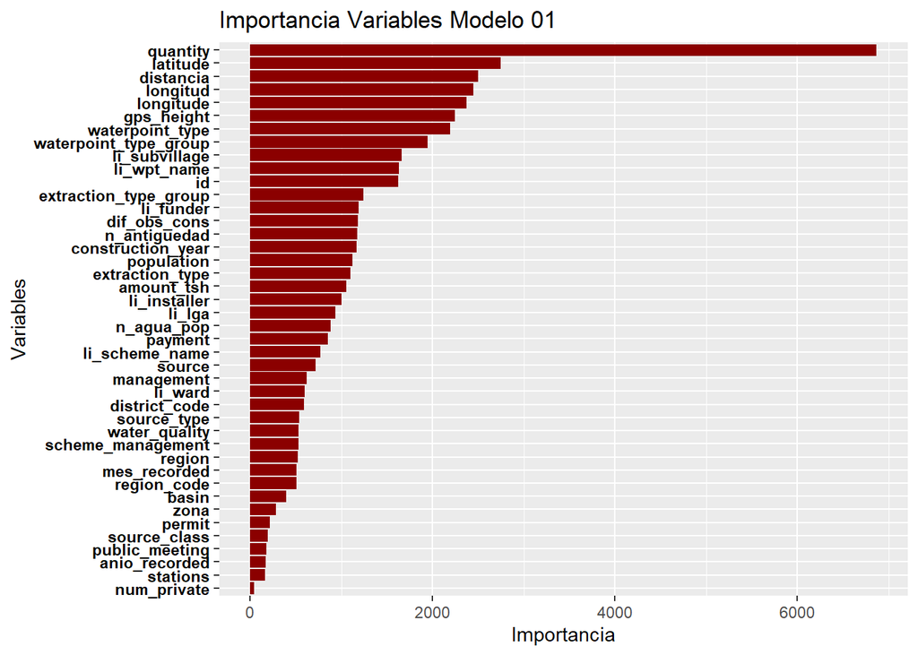

```r
show_importance_ggplot(my_model_1, title = "Importancia Variables Modelo 01" )
```

```r
#random_pred <- make_predictions(my_model_1, testclean)

# guardo submission

#fwrite(random_pred, file = "submission_entregable.csv")
```

En este modelo se observa una gran relevancia en la cantidad de agua que maneja la bomba, así como variables geográficas de longitud, latitud, distancia y altura gps. Por otra parte, se observa que hay relevancia en las variables relacionadas al tipo de fuente de agua. El modelo a pesar de tener un accuracy en local de 0.61 en los datos de test obtuvo un 0.71.

### Modelo con XGBOOST

Este algoritmo requiere que sean transformadas las variables categóricas, adicionalmente vimos que hay variables poco relevantes que podemos excluir del modelo

```r
traintestless<- traintestOriAll %>%
 select.(-waterpoint_type_group) %>% # duplicada con waterpoint_type
  select.(-num_private)%>%
 as.data.table()
```

#### Categóricas a numéricas

```r
# Listado de variables categoricas
cat_df_n <- traintestless %>%
  select.(where(is.character)) %>%
  mutate.(across.(where(is.character), ~ length(unique(.x)))) %>%
  distinct.() %>%
  pivot_longer.() %>% # transponer, para visualizar mejor la información
  arrange.(value) %>% # ordeno
  #filter.(value > 1) %>% # filtro las que tienen más de una categoría
  as.data.table()

# Imputación de las variables categoricas por sus frecuencias absolutas
cat_cols <- names(traintestless[, which(sapply(traintestless, is.character)), with = FALSE]) # vector de categoricas
for (cat_col in cat_cols) {traintestless[, paste0("cat_", cat_col) := as.numeric(.N), by = cat_col]}
for (cat_col in cat_cols) {traintestless[, paste(cat_col) := NULL]}
```

```r
# Dataframe final train
trainless <- traintestless %>%
  filter.(indice <= nrow(trainOri) ) %>%
  select.(-indice) %>%
  as.data.table()

# Dataframe final test
testless <- traintestless %>%
  filter.(indice > nrow(trainOri) ) %>%
  select.(-indice) %>%
  as.data.table()
```

#### Lanzamos el modelo XGBOOST

```r
vector_status_group = trainOriLab2$status_group

# Transformamos la variable objetivo en numerica
vector_status_group <- ifelse(vector_status_group == "functional", 0
                              , ifelse(vector_status_group == "functional needs repair", 1
                                       , 2))
xgb.train <- xgb.DMatrix(data=as.matrix(trainless), label = vector_status_group)

tic()
my_model_2 = xgb.train(
  seed = 1234,
  data   = xgb.train,
  params = list(
                objective = "multi:softmax",
                num_class = 3,
                colsample_bytree  = 0.3,
                colsample_bylevel = 0.9,
                colsample_bynode  = 0.75,
                max_depth         = 15,
                eta               = 0.02
                ),
  watchlist = list(val1 = xgb.train),
  verbose = 1,
  nrounds = 600,
  early_stopping_rounds = 20,
  nthread = 4,
  show_log_error = TRUE
)
toc()
```

#### Accuracy XGBOOST

```r
accuracy <- 1 - tail(my_model_2$evaluation_log$val1_mlogloss, 1)
accuracy
```

```
## [1] 0.8833173
```

#### Submission XGBOOST

```r
xgb_pred <- predict(my_model_2,as.matrix(testless),reshape = T)
xgb_pred <- ifelse(xgb_pred == 0, "functional",
                     ifelse(xgb_pred == 1,
                            "functional needs repair",
                            "non functional"
                     )
  )

xgb_pred <- data.table(id = testless$id, status_group = xgb_pred)
fwrite(xgb_pred, "submission_entregable.csv")
```

La documentacón para el balanceo en XGB sugiere que sea el parámetro se ajuste de la siguiente forma: sqrt(count(negative examples)/count(Positive examples)). Al tener un target que presenta 3 categorías, se utilizaria como casos negativos la categoría mayoritaria (“funcional”)y la positiva la minoritaria (“necesita reparación”)

#### Balanceo XGBOOST

```r
#1 Funcional
#2 Necesita reparación
#3 No funcional

length(as.numeric(trainOriLab$status_group[trainOriLab$status_group==1]))
```

```
## [1] 32259
```

```r
length(as.numeric(trainOriLab$status_group[trainOriLab$status_group==2]))
```

```
## [1] 4317
```

```r
sqrt(length(as.numeric(trainOriLab$status_group[trainOriLab$status_group==1]))/length(as.numeric(trainOriLab$status_group[trainOriLab$status_group==2])))
```

```
## [1] 2.733597
```

```r
length(as.numeric(trainOriLab$status_group[trainOriLab$status_group==1]))/length(as.numeric(trainOriLab$status_group[trainOriLab$status_group==2]))
```

```
## [1] 7.47255
```

```r
tic()
my_model_3 = xgb.train(
  seed = 1234,
  data   = xgb.train,
  params = list(
                objective = "multi:softmax",
                num_class = 3,
                colsample_bytree  = 0.3,
                colsample_bylevel = 0.9,
                colsample_bynode  = 0.75,
                max_depth         = 15,
                eta               = 0.02,
                scale_pos_weight= 6

                ),
  watchlist = list(val1 = xgb.train),
  verbose = 1,
  nrounds = 600,
  early_stopping_rounds = 20,
  nthread = 4,
  show_log_error = TRUE
)
toc()
```

#### Accuracy XGBOOST

```r
accuracy <- 1 - tail(my_model_3$evaluation_log$val1_mlogloss, 1)
accuracy
```

```
## [1] 0.8830451
```

```r
xgb_pred <- predict(my_model_3,as.matrix(testless),reshape = T)
xgb_pred <- ifelse(xgb_pred == 0, "functional",
                     ifelse(xgb_pred == 1,
                            "functional needs repair",
                            "non functional"
                     )
  )

xgb_pred <- data.table(id = testless$id, status_group = xgb_pred)
fwrite(xgb_pred, "submission_entregable5.csv")
```

### Modelo Random Forest H2O

```r
trainOriLab$status_group<-as.numeric(as.factor(trainOriLab$status_group))

trainlessLab<- trainless %>% inner_join(trainOriLab , by = "id")
```

```r
#-- Iniciamos el cluster h2o
h2o.init()
```

```r
h2o.no_progress()

 #-- Conversion train y test a objeto h2o
train_h2o <- as.h2o(trainlessLab)
test_h20  <- as.h2o(testless)
```

```r
#-- Lanzamos el modelo con las variables ya transformadas y limpias

# Defino variable objetivo
y <- "status_group"


train_h2o[,y] <- as.factor(train_h2o[,y])



mymodel <- h2o.randomForest(
                             y = y,
                             training_frame = train_h2o,
                             ntrees = 100
                            )
```

#### Importancia de las variables H20 Random Forest

```r
imp_h2o <- h2o.varimp(mymodel)
imp_df  <- as.data.frame(imp_h2o)
imp_df
```

| variable | relative_importance | scaled_importance | percentage |
| --- | --- | --- | --- |
| cat_quantity | 227571.391 | 1.00000000 | 0.130869884 |
| cat_waterpoint_type | 120772.523 | 0.53070170 | 0.069452869 |
| id | 93100.172 | 0.40910315 | 0.053539281 |
| gps_height | 86161.062 | 0.37861114 | 0.049548795 |
| latitude | 78616.352 | 0.34545797 | 0.045210045 |
| longitud | 76504.203 | 0.33617672 | 0.043995408 |
| cat_extraction_type | 66976.664 | 0.29431056 | 0.038516389 |
| distancia | 62748.184 | 0.27572967 | 0.036084709 |
| longitude | 59074.961 | 0.25958870 | 0.033972343 |
| cat_extraction_type_group | 58131.578 | 0.25544326 | 0.033429830 |

[output cut: 30 more lines]

| variable <chr> | relative_importance <dbl> | scaled_importance <dbl> | percentage <dbl> |  |
| --- | --- | --- | --- | --- |
| cat_quantity | 227571.391 | 1.00000000 | 0.130869884 |  |
| cat_waterpoint_type | 120772.523 | 0.53070170 | 0.069452869 |  |
| id | 93100.172 | 0.40910315 | 0.053539281 |  |
| gps_height | 86161.062 | 0.37861114 | 0.049548795 |  |
| latitude | 78616.352 | 0.34545797 | 0.045210045 |  |
| longitud | 76504.203 | 0.33617672 | 0.043995408 |  |
| cat_extraction_type | 66976.664 | 0.29431056 | 0.038516389 |  |
| distancia | 62748.184 | 0.27572967 | 0.036084709 |  |
| longitude | 59074.961 | 0.25958870 | 0.033972343 |  |
| cat_extraction_type_group | 58131.578 | 0.25544326 | 0.033429830 |  |

Vemos que el orden de importancia ha variado un poco respecto al primer modelo de random forest. Sin embargo, sigue apareciendo como variable más relevante la cantidad de agua de la fuente, donde vemos la variación, es en las variables relacionadas con la localización, en este modelo se prioriza el tipo de fuente de agua y el Id de la bomba.

#### Predict H20 Random Forest

```r
#-- Make Predictions
pred_h2o <- h2o.predict(mymodel, test_h20 )
pred_df  <- as.data.frame(pred_h2o)
pred_gd  <- pred_df %>%
  select.(predict) %>%
  as.data.table()
```

Con este modelo, se obtuvo un 0.8324 en la plataforma, cabe destacar que se realizó sin ajustar los hiperparámetros y sin utilizar los métodos de limpieza propios de H2o.

#### Submission H20 Random Forest

```r
mysub <- data.frame(
  id = testOri$id,
  status_group = as.vector(pred_gd$predict)
)

mysub$status_group <- ifelse(mysub$status_group == 1, "functional",
                     ifelse(mysub$status_group == 2,
                            "functional needs repair",
                            "non functional"
                     ))

fwrite(mysub, "submission_entregable6.csv")
```

### Modelo Autoxgboost

```r
#-- autoxgboost
options(error = NULL)
options(error = function(){.rs.recordTraceback(FALSE)})

bomba_agua <- makeClassifTask(data = as.data.frame(train_h2o), target = "status_group")

#  max.rounds:  numero maximo de iteraciones por modelo (indicamos un maximo de 600, el mejor
#               parametro obtenido hasta el momento)
#  time.budget: tiempo maximo de tuneo (lo establecemos a media hora: 1800 segundos)
my_model_autoxgboost  <- autoxgboost(bomba_agua, max.nrounds = 600, time.budget = 1800)
```

#### Submission Autoxgboost

```r
Auto_xgb_pred <- predict(my_model_autoxgboost,as.data.frame(testless),reshape = T)

Auto_xgb_pred <- ifelse(Auto_xgb_pred$data$response== 1, "functional",
                     ifelse(Auto_xgb_pred$data$response== 2,
                            "functional needs repair",
                            "non functional"
                     ))



Auto_xgb_pred <- data.table(id = testless$id, status_group = Auto_xgb_pred)
fwrite( Auto_xgb_pred, "submission_entregable7.csv")
```

Por último el Autoxgboost, a pesar de tener un buen resultado, por encima del 80%, sigue siendo inferior al obtenido en el XGB manual.

## Posibles Desarrollos Futuros

Para continuar con el concurso se podrían realizar toda la limpieza dentro del framework de H2o, adicionalmente se podrian utilizar otras ténicas en las variables de categorización, como puede ser el Hashing Encodig, o el Target Encoding para la variable objetivo. Adicionalmente, se podría utilizar Word Embedding para el procesamiento de las palabras en representación vectorial.